# Felony Disenfranchisement and the Voting-Eligible Population

Felony disenfranchisement, state by state, and a category that outlives the sentence

Democracy’s Data

Last updated September 13, 2026 at 10:53a EDT

In Vermont, a man serving a sentence for a felony — the graver class of crime, the kind that can carry more than a year in prison — votes. He votes from inside the prison, by absentee ballot, in the town where he lived before he was sentenced. Vermont has never taken the vote away for a criminal conviction, and neither has Maine.[^1] The same man, convicted of the same offense in Tennessee, does not vote in prison, on parole, on probation, or on the day his sentence ends. No federal rule governs the difference: every other boundary of the American electorate (age, citizenship, residency) was settled nationally, and this one was not. The Supreme Court held in *Richardson v. Ramirez* (1974) that the Constitution permits a state to take the vote away for a crime, and left the rest to each state.[^2] **Who is barred from voting by a felony conviction — felony disenfranchisement, in the law’s phrase — and how would anyone even count them?**

## The test

The test is to read the one count that exists. There is no federal register of disenfranchised Americans; no agency is required to produce one, and none does. The figure that appears in litigation, journalism and the academic literature is built by a research organization. The Sentencing Project, a research and advocacy group in Washington, has published the *Locked Out* series since the late 1990s; the 2024 edition, written by the sociologist Christopher Uggen and three colleagues, prints one row per state, and is downloadable at https://www.sentencingproject.org/reports/locked-out-2024-four-million-denied-voting-rights-due-to-a-felony-conviction/. It takes the counts of people in prison, in jail, on parole and on probation from the Bureau of Justice Statistics, the federal agency that publishes them every year,[^3] and reads them against what each state’s law says about who in those populations may vote.

That is the right evidence, and for a reason worth stating exactly. It is not the only estimate one could build; it is the estimate that *operates* — the one courts cite and legislatures argue about. The subject also completes this cluster’s picture of the registration list. The voter-file chapter reads the file of people the state let in; this brief counts the people state law keeps out, who appear in no file at all.

## The data

The count is published as a table in a PDF report, with no spreadsheet, no data file and no supplement. The numbers here were read off that table column by column, and reading a table out of a PDF is fragile in a specific way: nothing but position on the page separates one column from the next, so a boundary two characters off corrupts a row silently. So every row is checked against a property the report guarantees — the five categories are mutually exclusive and must add to the state total.

| Check | Result |
| --- | --- |
| The test | prison + parole + probation + jail + post-sentence = total |
| States summing exactly | 43 |
| States off by exactly 1 person | 7 |
| States off by more than 1 | 0 |
| Largest discrepancy anywhere | 1 |

43 states sum exactly and 7 are off by a single person, which is rounding in the published report, not a reading error. The check earned its place: a first reading cut Texas’s row two characters too far to the right and produced discrepancies in the tens of thousands.

Two cleaning decisions carry meaning. A blank cell is read as `0`, and that is a claim rather than a convenience. It says the category does not exist in that state’s law, not that the number is missing, and the report’s own text supports it. And the rate column `pct` is taken as printed rather than recomputed, so the brief argues with the report instead of with itself; the two agree to within 0.005 of a point everywhere.

What comes out is three tables. `states.csv` carries, for each state, the five categories (`prison`, `jail`, `parole`, `probation`, `post_sentence`), plus `total`, the printed `pct`, and `voting_eligible_pop` — the denominator, meaning the bottom number each rate is divided by. `national.csv` holds the same categories for the country. `grid.csv` is only a map layout. One row reads like this:

| State | Prison | Jail | Parole | Probation | Post-sentence | Total | % of adult citizens |
| --- | --- | --- | --- | --- | --- | --- | --- |
| Tennessee | 23,735 | 7,480 | 12,630 | 55,673 | 300,166 | 399,684 | 7.68 |
| Florida | 84,678 | 10,007 | 3,890 | 133,324 | 729,858 | 961,757 | 6.13 |
| Pennsylvania | 37,910 | 3,372 | 0 | 0 | 0 | 41,282 | 0.41 |

The five categories divide by two questions. Prison and jail are people currently held. Parole and probation are people under supervision, living in the community: **parole** is release from prison before the sentence is up, on conditions, and **probation** is a sentence served under supervision instead of behind bars. **Post-sentence** are people who have finished the sentence entirely, every day served and every condition met — and are still barred.

Tennessee’s row, the top of the table, is built like every other. 23,735 people in prison, 7,480 in jail, 12,630 on parole and 55,673 on probation, then 300,166 who have finished their sentences: together 399,684. Divide by the state’s 5,206,668 adult citizens and the rate is 7.68%. Pennsylvania’s row has the same shape with three zeros in it. The state bars only the 41,282 people actually held, so its rate is 0.41%; the zeros are the law, not missing data.

> **Before you read on, commit to a number.** Across the 50 states in this file, the average among those that disenfranchise anyone at all is 1.53% of adult citizens. **How many times that average is the single highest state?** Write down a multiple. Then write down how many states you think bar nobody at all.

## What it says about democracy

| Quantity | Value |
| --- | --- |
| Total disenfranchised | 4,049,978 |
| Voting-eligible population | 237,630,249 |
| Share of adult citizens | 1.7% |
| Currently incarcerated | 1,153,648 (28.5%) |
| Not incarcerated | 2,896,330 (71.5%) |

About 4,049,978 American adult citizens, 1.7% of the total, cannot vote because of a felony conviction. The first thing the breakdown says is that the intuitive picture is wrong: **71.5% of them are not in prison or jail.** Nearly three quarters of the disenfranchised population is living in the community, working, paying taxes, raising children.

| Category | People | Share | Incarcerated | Sentence complete |
| --- | --- | --- | --- | --- |
| Prison | 1,034,995 | 25.6 | yes | no |
| Jail | 118,653 | 2.9 | yes | no |
| Parole | 286,168 | 7.1 | no | no |
| Probation | 993,725 | 24.5 | no | no |
| Post-sentence | 1,616,437 | 39.9 | no | yes |

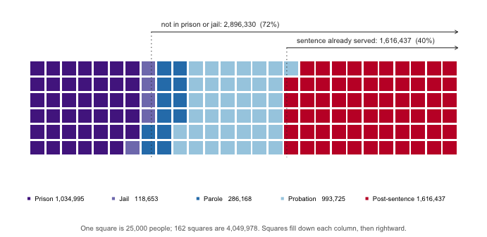

One square is 25,000 people; 162 squares are 4,049,978. Squares fill down each column, then rightward, so the dotted lines fall at the exact share.

**Figure 1. The disenfranchised population of the United States, one square per 25,000 people.** A unit chart fits this question because the finding is about proportions of one population, and the two dotted cut lines can be read against each other. Everything right of the first line, 72% of the whole, is not incarcerated; everything right of the second, 40%, has completed its sentence in full.

The largest category is the one that is already over. **1,616,437 people, 39.9% of the total, have completed their sentences and still cannot vote** — more than prison and jail put together. And it is not a national policy operating everywhere at modest scale:

| State | Post-sentence | State total | % of state’s total |
| --- | --- | --- | --- |
| Florida | 729,858 | 961,757 | 75.9 |
| Tennessee | 300,166 | 399,684 | 75.1 |
| Alabama | 181,056 | 227,437 | 79.6 |
| Virginia | 169,573 | 264,292 | 64.2 |
| Arizona | 112,109 | 214,791 | 52.2 |
| Kentucky | 71,829 | 158,381 | 45.4 |
| Mississippi | 47,932 | 68,731 | 69.7 |
| Wyoming | 2,907 | 9,437 | 30.8 |
| Iowa | 651 | 26,878 | 2.4 |
| Delaware | 357 | 6,214 | 5.7 |

**10 states account for the entire post-sentence category**; the other 40 have none of it. Inside those ten it is no fringe: 76% of Florida’s disenfranchised, 75% of Tennessee’s, have already finished their sentences. These are people for whom a completed sentence carries a permanent civic consequence that no judge imposed and no date ends.

| State | Disenfranchised | % of adult citizens |
| --- | --- | --- |
| Tennessee | 399,684 | 7.68 |
| Florida | 961,757 | 6.13 |
| Alabama | 227,437 | 5.95 |
| Kentucky | 158,381 | 4.66 |
| Arizona | 214,791 | 4.20 |
| Virginia | 264,292 | 4.18 |
| Maine | 0 | 0.00 |
| Vermont | 0 | 0.00 |
| Massachusetts | 7,360 | 0.14 |
| Rhode Island | 1,595 | 0.19 |

A reader who took the prompt above probably wrote down two or three times the average. Tennessee disenfranchises 7.68% of its adult citizens, 5.0 times the average of the states that bar anyone at all — and 2 states disenfranchise nobody. The same conviction costs a vote in one state and nothing in the state next door.

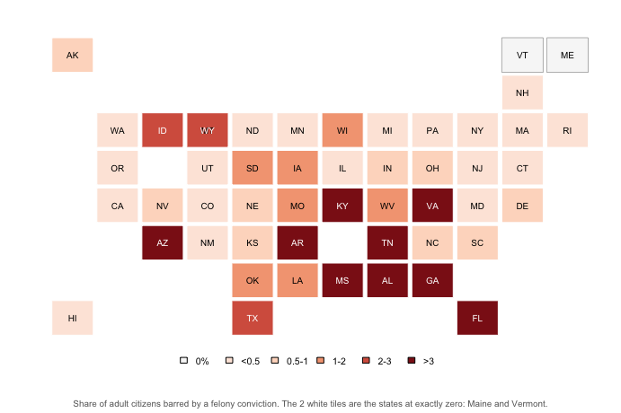

One tile per state, laid out roughly geographically. Hover for counts and the post-sentence figure.

**Figure 2. Share of adult citizens barred by a felony conviction, by state.** One tile per state in a rough geographic layout, because the finding is regional: the dark tiles are the South plus Arizona, and the 2 white tiles are Maine and Vermont, at exactly zero. Those states face the same criminal law as their neighbours; the variation is a policy choice, not a crime rate.

Every percentage above divides by what the report calls a **voting-eligible population**: adult citizens, with the disenfranchised themselves still counted among them. The phrase usually means something stricter — the political scientist Michael McDonald, who coined it, subtracts the people the law bars[^4] — and either way the denominator is itself an estimate. “Adult citizens” requires knowing who is a citizen, which requires a survey:

| Quantity | Value |
| --- | --- |
| National voting-eligible population used here | 237,630,249 |
| Where it comes from | Estimated adult citizen population |
| Is the disenfranchised count subtracted from it? | No |

So 7.68% in Tennessee means “this share of adult citizens is barred,” and both halves of the fraction are estimates rather than counts. The consequences reach past this brief. Turnout is a fraction too, and disenfranchisement changes its denominator, so comparing turnout across states silently compares different electorates. Representation is apportioned by *population*, and the census counts prisoners where they are held:[^5] a disenfranchised person is counted for apportionment and excluded from the electorate. And because felony conviction rates differ sharply by race, the bar falls on one Black adult in 22 — 4.5% of Black adults against 1.3% of everyone else, 3.5 times the rate, by the report’s own estimate.[^6] This file cannot show that; the literature, beginning with Uggen and Manza (2002), has documented it repeatedly.[^7]

Florida shows what an uncounted population costs in practice. Amendment 4, passed in 2018 with 64.55% of the vote, restored rights to most people who had completed their sentences; the legislature then required outstanding fines and fees to be paid first.[^8] **Florida keeps no reliable central record of what any given person owes**, so many affected people cannot establish whether they are eligible, and registering while ineligible is itself a crime. Florida remains the largest post-sentence population in this file, at 729,858 people. That is a data problem producing a rights problem.

## What this brief cannot tell you

**Whether the count is right.** It is a single organization’s estimate of a number no government produces, so there is no independent figure to check it against. The sum test above validates the parse and says nothing about the underlying numbers. The post-sentence category especially is modeled from decades of convictions, minus deaths, reconvictions and moves, rather than read off any roll.

**Who the barred people are.** The file carries no race, age or sex, so the racial disparity that motivates most of the literature can only be cited here, not computed.

**How the law actually reads.** Several states attach conditions no five-category table can express. The jail figures are the softest in the file, because jail populations turn over quickly. And the count is one point in time, in a subject that changes every legislative session.

**And how many of these people would vote.** Registration and turnout among restored populations run low, which cuts against the simplest electoral-effect claims; nothing in this file measures it.[^9]

## What you should have learned

- Roughly 4,049,978 adult citizens, 1.7% of the voting-eligible population, are barred from voting by a felony conviction, and nobody in government counts them.
- 71.5% of the disenfranchised are not incarcerated, and 39.9% have completed their sentences entirely — the single largest category.
- The bar is uneven by design: Tennessee bars 7.68% of its adult citizens, 5.0 times the average among states that bar anyone, while Maine and Vermont bar nobody.
- 10 states hold the entire post-sentence category; Florida alone holds 729,858 people, 45% of it.
- The number is estimated rather than counted: its numerator is modeled from correctional data read against state law, and its voting-eligible denominator is itself a survey-based estimate.

## Extensions

None of these is answered above, and every one can be answered from the tables the Sources section hands over.

- `states.csv` breaks each state’s total into `prison`, `jail`, `parole`, `probation` and `post_sentence`. Sort by `post_sentence`. Which states bar the most people whose sentences are finished?
- `states.csv` gives each state a `pct` of its `voting_eligible_pop`. Find the highest and lowest nonzero rates, then check whether the difference tracks prison populations or the law’s reach after release.
- `national.csv` carries the same five categories nationally. Work out what share of the total the phrase “felon voting” — people currently in prison — actually describes.
- `states.csv` lets you build the counterfactual: sum `post_sentence` and ask what share of the national total would be restored if every state ended post-sentence bars tomorrow.

Two stretch ideas point past the spreadsheet. Pick one state and list what would have to be counted, by whom, for its row to be exactly right — you will find no agency owns most of the pieces. And find the next edition of *Locked Out* when it appears. The parse here is pinned to the 2024 printing, so reading the new PDF is real work, and comparing the two editions state by state is a finding.

## Sources

**Data**

- The Sentencing Project, *Locked Out: Estimates of People Denied Voting Rights Due to a Felony Conviction*, 2024 edition — the state table in the published PDF report, which has no spreadsheet beside it. The three tables every number here is computed from were read off that table, row by row, and checked with the sum test quoted above. https://www.sentencingproject.org/; the report itself is Uggen, C., Larson, R., Shannon, S. and Stewart, R. (2024), *Locked Out 2024: Four Million Denied Voting Rights Due to a Felony Conviction*, https://www.sentencingproject.org/reports/locked-out-2024-four-million-denied-voting-rights-due-to-a-felony-conviction/, PDF at https://www.sentencingproject.org/app/uploads/2024/10/Locked-Out-2024-Four-Million-Denied-Voting-Rights-Due-to-a-Felony-Conviction.pdf (the state table is its Table 2).
- Bureau of Justice Statistics, the source of the report’s prison, jail, parole and probation counts. https://bjs.ojp.gov/topics/corrections

**Academic literature**

- Uggen, C. and Manza, J. (2002). “Democratic Contraction? Political Consequences of Felon Disenfranchisement in the United States.” *American Sociological Review* 67(6): 777–803. https://www.jstor.org/stable/3088970
- McDonald, M. P. and Popkin, S. L. (2001). “The Myth of the Vanishing Voter.” *American Political Science Review* 95(4): 963–974. https://www.jstor.org/stable/3117725
- Gerber, A. S., Huber, G. A., Meredith, M., Biggers, D. R. and Hendry, D. J. (2015). “Can Incarcerated Felons Be (Re)integrated into the Political System? Results from a Field Experiment.” *American Journal of Political Science* 59(4): 912–926. https://www.sas.upenn.edu/~marcmere/workingpapers/CTFelon.pdf
- *Richardson v. Ramirez*, 418 U.S. 24 (1974). https://www.law.cornell.edu/supremecourt/text/418/24
- *Jones v. Governor of Florida*, 975 F.3d 1016 (11th Cir. 2020) (en banc). https://media.ca11.uscourts.gov/opinions/pub/files/202012003.enb.pdf

**The data itself**

Every figure above is drawn from these tables. They are plain CSV, they open in a spreadsheet, and they are yours to take further.

`grid.csv`, `national.csv`, `states.csv`

Rebuild this data yourself, with an AI assistant

```
I want to rebuild a public dataset from its original source, without
any starting files. Please do the following and show your work.

THE SOURCE. The Sentencing Project, "Locked Out 2024: Four Million
Denied Voting Rights Due to a Felony Conviction", by Uggen, Larson,
Shannon and Stewart, October 2024. It is a PDF report, not a
dataset:
https://www.sentencingproject.org/app/uploads/2024/10/Locked-Out-2024-Four-Million-Denied-Voting-Rights-Due-to-a-Felony-Conviction.pdf
The state-by-state numbers exist only as Table 2, on page 18. One
row is a state: people disenfranchised while in prison, on parole,
on probation, in jail, and after completing their sentence, plus the
total, the voting-eligible population, and the rate. The District of
Columbia is not in the table. No account or key is needed.

HOW TO DOWNLOAD IT. The download is plain, but the extraction is not.
Use poppler's pdftotext with its layout option so the table's
columns keep their positions, then read the columns by position, not
by pattern. Blank cells carry meaning -- California disenfranchises
only people in prison, Maine and Vermont nobody at all -- so a
pattern that expects a number in every column silently drops exactly
the most interesting states. Check every row you parse: the five
category columns must sum to the total.

WHAT TO BUILD.
1. One row per state with the five category counts, the total, the
   voting-eligible population, and the rate, plus one national line.
2. The sum check above, reported for all fifty states.

CHECK YOUR WORK. The copy this book used was downloaded in August 2026.
If your rebuild matches it, you should find:
- 4,049,978 people disenfranchised nationally -- 1.70 percent of a
  voting-eligible population of 237,630,249
- 1,616,437 of them have completed their sentences entirely
- Tennessee has the highest rate, 7.68 percent, from a total of
  399,684; Maine and Vermont are exactly zero
- all fifty state rows pass the sum check
The report is revised roughly every two years; a later edition
changes every state's numbers because the estimates were redone, not
because you made an error.
```

[^1]: The National Conference of State Legislatures keeps the state-by-state rules: https://www.ncsl.org/elections-and-campaigns/felon-voting-rights.
[^2]: *Richardson v. Ramirez*, 418 U.S. 24 (1974), https://www.law.cornell.edu/supremecourt/text/418/24.
[^3]: https://bjs.ojp.gov/topics/corrections.
[^4]: Michael P. McDonald and Samuel L. Popkin, “The Myth of the Vanishing Voter,” *American Political Science Review* 95, no. 4 (2001): 963–974, https://www.jstor.org/stable/3117725.
[^5]: The Census Bureau’s residence rules for the 2020 count, which place people in prison at the facility: https://www.federalregister.gov/documents/2018/02/08/2018-02370/final-2020-census-residence-criteria-and-residence-situations.
[^6]: *Locked Out 2024*, pp. 4 and 15.
[^7]: Christopher Uggen and Jeff Manza, “Democratic Contraction? Political Consequences of Felon Disenfranchisement in the United States,” *American Sociological Review* 67, no. 6 (2002): 777–803, https://www.jstor.org/stable/3088970.
[^8]: The condition is Fla. Stat. §98.0751, http://www.leg.state.fl.us/statutes/index.cfm?App_mode=Display_Statute&URL=0000-0099/0098/Sections/0098.0751.html. The vote, the statute and the state of Florida’s records are all set out in *Jones v. Governor of Florida*, 975 F.3d 1016 (11th Cir. 2020) (en banc), https://media.ca11.uscourts.gov/opinions/pub/files/202012003.enb.pdf, which quotes the Florida Department of State’s own analysis for the legislature that “no single source exists” to confirm what a person owes.
[^9]: A field experiment in Connecticut found that, left alone, only a small minority of people released from prison had registered and fewer still had voted, and that a letter from the Secretary of State telling them they were eligible raised both by under two percentage points: Alan S. Gerber, Gregory A. Huber, Marc Meredith, Daniel R. Biggers and David J. Hendry, “Can Incarcerated Felons Be (Re)integrated into the Political System? Results from a Field Experiment,” *American Journal of Political Science* 59, no. 4 (2015): 912–926, https://www.sas.upenn.edu/~marcmere/workingpapers/CTFelon.pdf. See also Marc Meredith and Michael Morse, “Do Voting Rights Notification Laws Increase Ex-Felon Turnout?” *Annals of the American Academy of Political and Social Science* 651 (2014): 220–249, doi:10.1177/0002716213502931 (the publisher refuses automated requests, so the address is given as text).